# Solutions for Guided Project: Exploring NYC Schools Survey Data

Rose Martin

**Here are suggested solutions to the questions in the Data Cleaning With R Guided Project: Exploring NYC Schools Survey Data.**

Load the packages you’ll need for your analysis

```r
library(readr)
library(dplyr)
```

```r
library(stringr)
library(purrr)
library(tidyr)
library(ggplot2)
```

Import the data into R.

```r
combined <- read_csv("combined.csv")
survey <- read_tsv("survey_all.txt")
survey_d75 <- read_tsv("survey_d75.txt")
```

Filter `survey` data to include only high schools and select columns needed for analysis based on the data dictionary.

```r
survey_select <- survey %>%
  filter(schooltype == "High School") %>%
  select(dbn:aca_tot_11)
```

Select columns needed for analysis from `survey_d75`.

```r
survey_d75_select <- survey_d75 %>%
  select(dbn:aca_tot_11)
```

Combine `survey` and `survey_d75` data frames.

```r
survey_total <- survey_select %>%
  bind_rows(survey_d75_select)
```

Rename `survey_total` variable `dbn` to `DBN` so can use as key to join with the `combined` data frame.

```r
survey_total <- survey_total %>%
  rename(DBN = dbn)
```

Join the `combined` and `survey_total` data frames. Use `left_join()` to keep only survey data that correspond to schools for which we have data in `combined`.

```r
combined_survey <- combined %>%
  left_join(survey_total, by = "DBN")
```

Create a correlation matrix to look for interesting relationships between pairs of variables in `combined_survey` and convert it to a tibble so it’s easier to work with using tidyverse tools.

```r
cor_mat <- combined_survey %>%    ## interesting relationshipsS
  select(avg_sat_score, saf_p_11:aca_tot_11) %>%
  cor(use = "pairwise.complete.obs")

cor_tib <- cor_mat %>%
  as_tibble(rownames = "variable")
```

Look for correlations of other variables with `avg_sat_score` that are greater than 0.25 or less than -0.25 (strong correlations).

```r
strong_cors <- cor_tib %>%
  select(variable, avg_sat_score) %>%
  filter(avg_sat_score > 0.25 | avg_sat_score < -0.25)
```

Make scatter plots of those variables with `avg_sat_score` to examine relationships more closely.

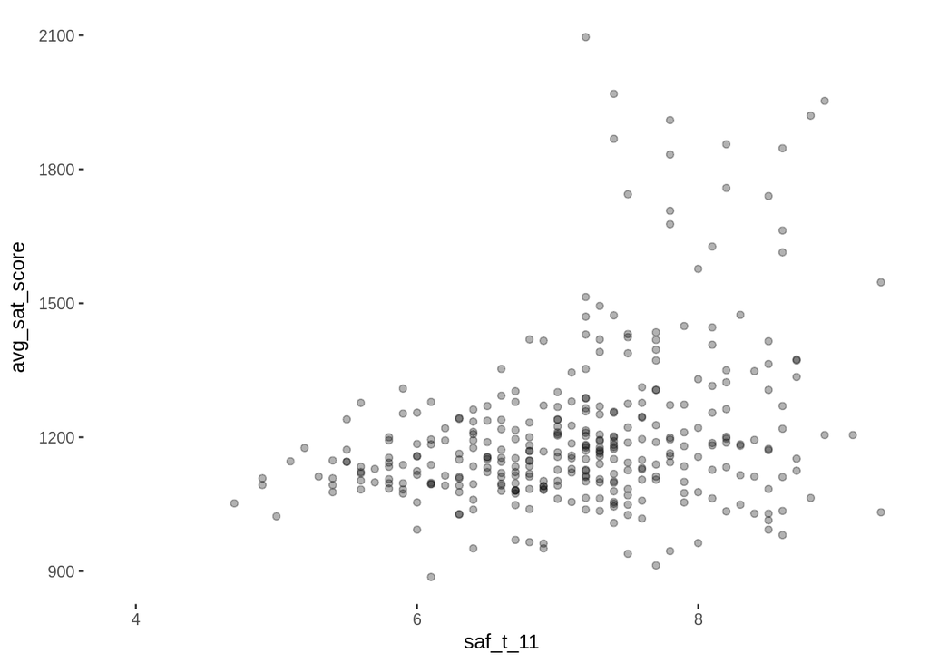

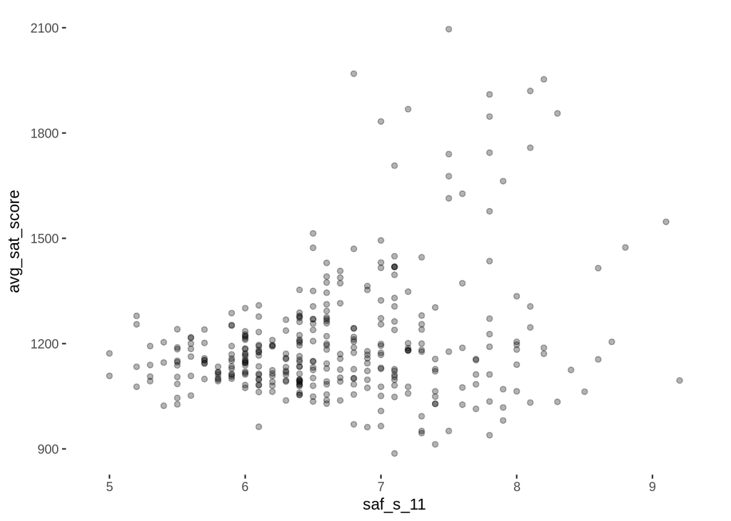

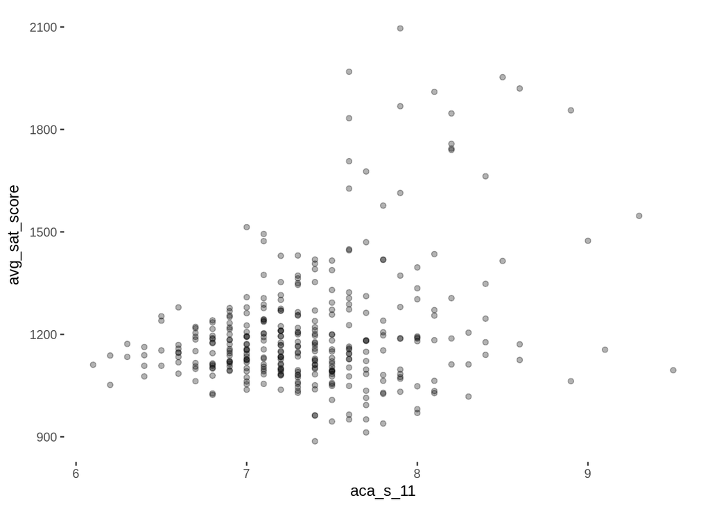

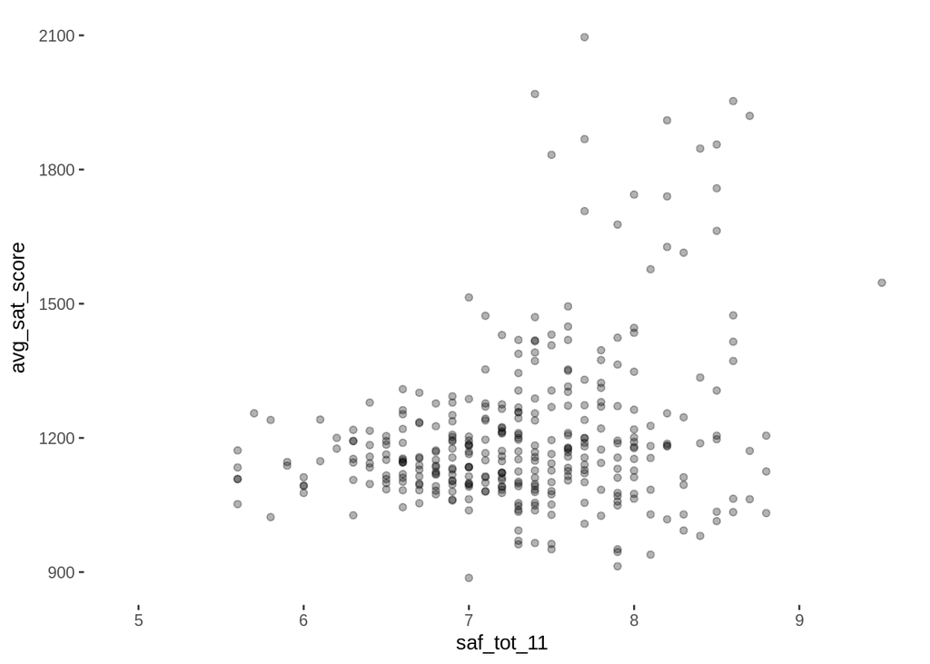

```r
create_scatter <- function(x, y) {
  ggplot(data = combined_survey) +
    aes_string(x = x, y = y) +
    geom_point(alpha = 0.3) +
    theme(panel.background = element_rect(fill = "white"))
}

x_var <- strong_cors$variable[2:5]
y_var <- "avg_sat_score"

map2(x_var, y_var, create_scatter)
```

Reshape the data so that you can investigate differences in student, parent, and teacher responses to survey questions.

```r
combined_survey_gather <- combined_survey %>%
  gather(key = "survey_question", value = score, saf_p_11:aca_tot_11)
```

Use `str_sub()` to create new variables, `response_type` and `question`, from the `survey_question` variable.

```r
combined_survey_gather <- combined_survey_gather %>%
  mutate(response_type = str_sub(survey_question, 4, 6)) %>%
  mutate(question = str_sub(survey_question, 1, 3))
```

Replace `response_type` variable values with names “parent”, “teacher”, “student”, “total” using `if_else()` function.

```r
combined_survey_gather <- combined_survey_gather %>%
  mutate(response_type = ifelse(response_type  == "_p_", "parent",
                                ifelse(response_type == "_t_", "teacher",
                                       ifelse(response_type == "_s_", "student",
                                              ifelse(response_type == "_to", "total", "NA")))))
```

Make a boxplot to see if there appear to be differences in how the three groups of responders (parents, students, and teachers) answered the four questions.

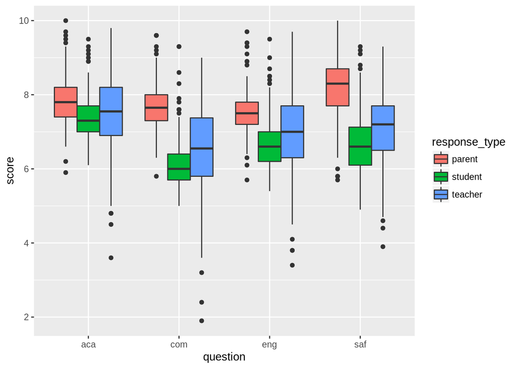

```r
combined_survey_gather %>%
  filter(response_type != "total") %>%
  ggplot() +
  aes(x = question, y = score, fill = response_type) +
  geom_boxplot()
```